# Code Along 2

Predicting Chocolate Ratings

*This template offers an opinionated guide on how to structure a modeling analysis. Your individual modeling analysis may require you to add to, subtract from, or otherwise change this structure, but consider this a general framework to start from. If you want to learn more about using tidymodels, check out our [Getting Started](https://www.tidymodels.org/start/) guide.*

Our modeling goal is to predict ratings for chocolate based on the main characteristics as described by the raters.

```r
library(tidyverse)
library(tidytext)

url <- "https://raw.githubusercontent.com/rfordatascience/tidytuesday/master/data/2022/2022-01-18/chocolate.csv"
chocolate <- read_csv(url)
```

## Explore data

Exploratory data analysis (EDA) is an [important part of the modeling process](https://www.tmwr.org/software-modeling.html#model-phases).

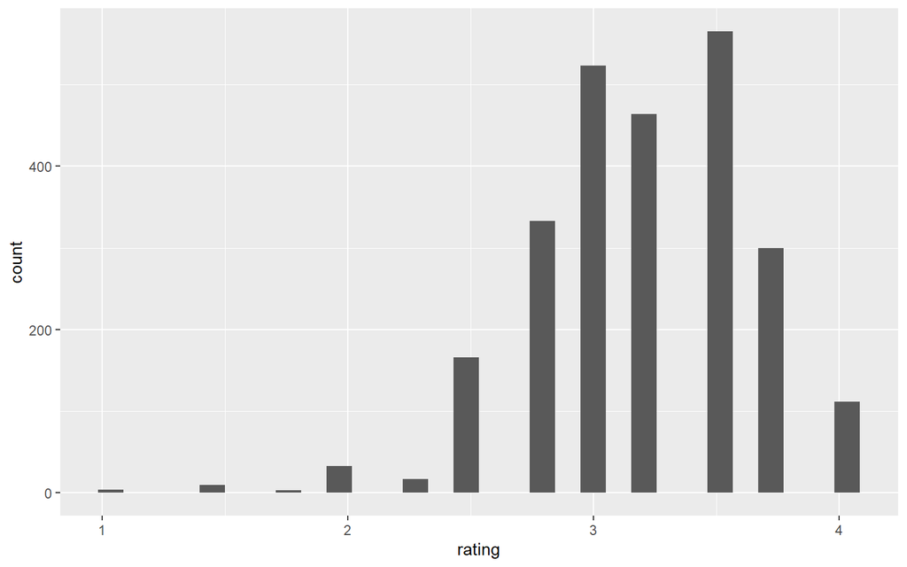

```r
chocolate %>%
    ggplot(aes(rating)) +
    geom_histogram()
```

```r
tidy_chocolate <- chocolate %>%
    unnest_tokens(word, most_memorable_characteristics)

tidy_chocolate %>%
    count(word, sort = TRUE)
```

```
## # A tibble: 547 × 2
##    word        n
##    <chr>   <int>
##  1 cocoa     419
##  2 sweet     318
##  3 nutty     278
##  4 fruit     273
##  5 roasty    228
##  6 mild      226
##  7 sour      208
##  8 earthy    199
##  9 creamy    189
## 10 intense   178
## # … with 537 more rows
```

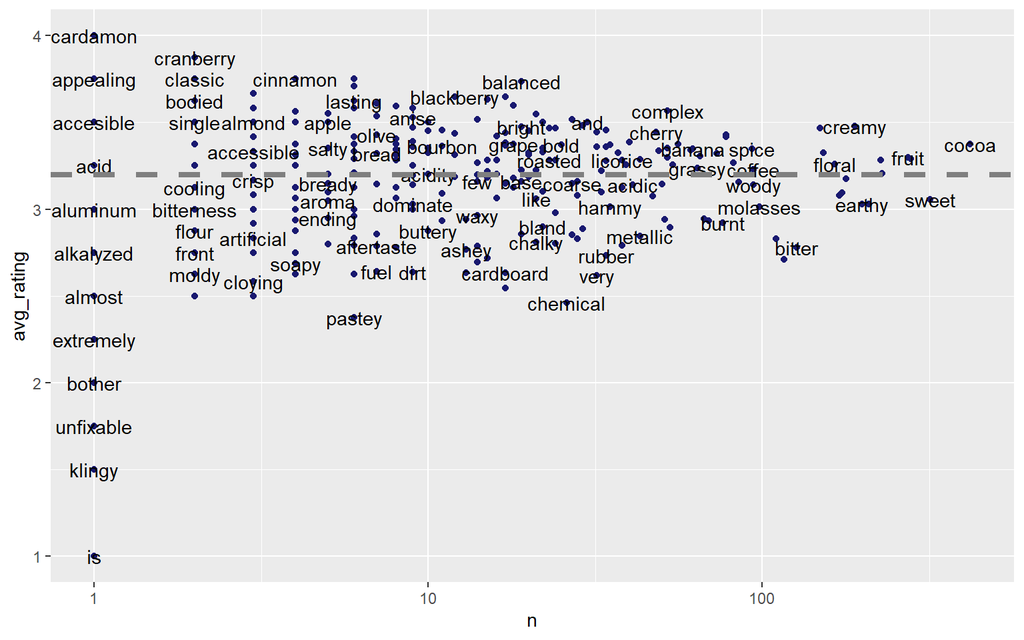

```r
tidy_chocolate %>%
    group_by(word) %>%
    summarise(n = n(),
              avg_rating = mean(rating)) %>%
    ungroup() %>%

    ggplot(aes(n, avg_rating)) +
    geom_point(color = "midnightblue") +
    geom_text(aes(label = word),
              check_overlap = TRUE) +
    geom_hline(yintercept = mean(chocolate$rating),
               lty = 2, color = "gray50", linewidth = 1.5) +
    scale_x_log10()
```

## Build models

Let’s consider how to [spend our data budget](https://www.tmwr.org/splitting.html):

- create training and testing sets
- create resampling folds from the *training* set

```r
library(tidymodels)
set.seed(123)
choco_split <- initial_split(chocolate, strata = rating)
choco_train <- training(choco_split)
choco_test <- testing(choco_split)

set.seed(234)
choco_folds <- vfold_cv(choco_train, strata = rating)
choco_folds
```

```
## #  10-fold cross-validation using stratification
## # A tibble: 10 × 2
##    splits             id
##    <list>             <chr>
##  1 <split [1705/191]> Fold01
##  2 <split [1705/191]> Fold02
##  3 <split [1705/191]> Fold03
##  4 <split [1706/190]> Fold04
##  5 <split [1706/190]> Fold05
##  6 <split [1706/190]> Fold06
##  7 <split [1707/189]> Fold07
##  8 <split [1707/189]> Fold08
##  9 <split [1708/188]> Fold09
## 10 <split [1709/187]> Fold10
```

```r
library(textrecipes)

choco_rec <-
    recipe(rating ~ most_memorable_characteristics,
           data = choco_train) %>%
    step_tokenize(most_memorable_characteristics) %>%
    step_tokenfilter(most_memorable_characteristics, max_tokens = 300) %>%
    step_tf(most_memorable_characteristics)

choco_prep <- prep(choco_rec)
bake(choco_prep, new_data = NULL)
```

```
## # A tibble: 1,896 × 301
##    rating tf_most_memo…¹ tf_mo…² tf_mo…³ tf_mo…⁴ tf_mo…⁵ tf_mo…⁶ tf_mo…⁷ tf_mo…⁸
##     <dbl>          <int>   <int>   <int>   <int>   <int>   <int>   <int>   <int>
##  1   3                 0       0       0       0       0       0       0       0
##  2   2.75              0       0       0       0       0       0       0       0
##  3   3                 0       0       0       0       0       0       0       0
##  4   3                 0       0       0       0       0       0       0       0
##  5   2.75              0       0       0       0       0       0       0       0
##  6   3                 0       1       0       0       0       0       0       0
##  7   2.75              0       0       0       0       0       0       0       0
##  8   2.5               0       0       0       0       0       0       0       0
##  9   2.75              0       0       0       0       0       0       0       0
## 10   3                 0       0       0       0       0       0       0       0
## # … with 1,886 more rows, 292 more variables:
## #   tf_most_memorable_characteristics_apple <int>,
## #   tf_most_memorable_characteristics_aroma <int>,
## #   tf_most_memorable_characteristics_ashey <int>,
## #   tf_most_memorable_characteristics_astringency <int>,
## #   tf_most_memorable_characteristics_astringent <int>,
## #   tf_most_memorable_characteristics_atypical <int>, …
```

Let’s create a [**model specification**](https://www.tmwr.org/models.html) for each model we want to try:

```r
svm_spec <-
    svm_linear() %>%
    set_engine("LiblineaR") %>%
    set_mode("regression")

ranger_spec <-
  rand_forest(trees = 1e3) %>%
  set_engine("ranger") %>%
  set_mode("regression")
```

To set up your modeling code, consider using the [parsnip addin](https://parsnip.tidymodels.org/reference/parsnip_addin.html) or the [usemodels](https://usemodels.tidymodels.org/) package.

Now let’s build a [**model workflow**](https://www.tmwr.org/workflows.html) combining each model specification with a data preprocessor:

```r
svm_wf    <- workflow(choco_rec, svm_spec)
ranger_wf <- workflow(choco_rec, ranger_spec)
```

If your feature engineering needs are more complex than provided by a formula like `sex ~ .`, use a [recipe](https://www.tidymodels.org/start/recipes/). [Read more about feature engineering with recipes](https://www.tmwr.org/recipes.html) to learn how they work.

## Evaluate models

These models have no tuning parameters so we can evaluate them as they are. [Learn about tuning hyperparameters here.](https://www.tidymodels.org/start/tuning/)

```r
doParallel::registerDoParallel()
control_preds <- control_resamples(save_pred = TRUE)

svm_rs <- fit_resamples(
    svm_wf,
    choco_folds,
    control = control_preds
)

ranger_rs <- fit_resamples(
    ranger_wf,
    choco_folds,
    control = control_preds
)
```

How did these two models compare?

```r
collect_metrics(svm_rs)
```

```
## # A tibble: 2 × 6
##   .metric .estimator  mean     n std_err .config
##   <chr>   <chr>      <dbl> <int>   <dbl> <chr>
## 1 rmse    standard   0.332    10 0.00770 Preprocessor1_Model1
## 2 rsq     standard   0.423    10 0.0181  Preprocessor1_Model1
```

```r
collect_metrics(ranger_rs)
```

```
## # A tibble: 2 × 6
##   .metric .estimator  mean     n std_err .config
##   <chr>   <chr>      <dbl> <int>   <dbl> <chr>
## 1 rmse    standard   0.334    10 0.00758 Preprocessor1_Model1
## 2 rsq     standard   0.426    10 0.0162  Preprocessor1_Model1
```

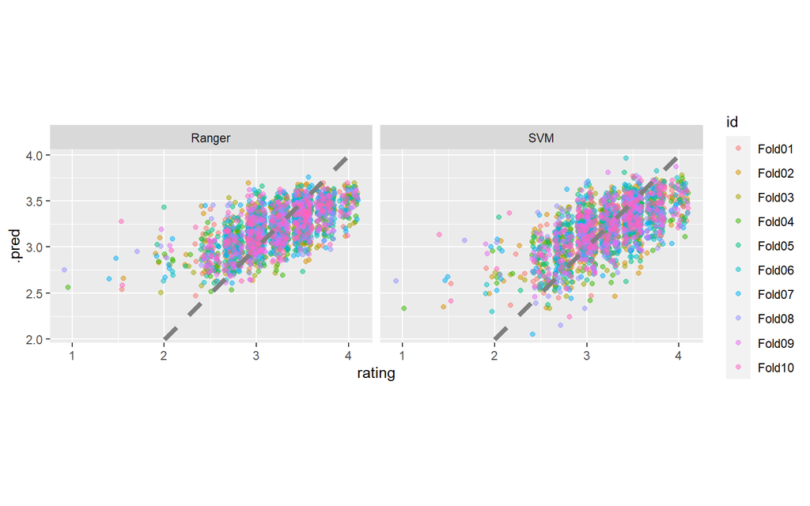

```r
bind_rows(
    collect_predictions(svm_rs) %>%
    mutate(mod = "SVM"),
    collect_predictions(ranger_rs) %>%
    mutate(mod = "Ranger")
) %>%

    ggplot(aes(rating, .pred, col = id)) +
    geom_jitter(alpha = 0.5) +
    geom_abline(lty = 2, linewidth = 1.5, col = "gray50") +
    facet_wrap(~mod) +
    coord_fixed()
```

These models perform very similarly, so perhaps we would choose the simpler, linear model. The function `last_fit()` *fits* one final time on the training data and *evaluates* on the testing data. This is the first time we have used the testing data.

```r
svm_last <- last_fit(svm_wf, choco_split)
```

This object contains a fitted workflow that we can use for prediction.

```r
collect_metrics(svm_last)
```

```
## # A tibble: 2 × 4
##   .metric .estimator .estimate .config
##   <chr>   <chr>          <dbl> <chr>
## 1 rmse    standard       0.364 Preprocessor1_Model1
## 2 rsq     standard       0.408 Preprocessor1_Model1
```

```r
svm_last %>%
    extract_workflow() %>%
    predict(choco_test[1,])
```

```
## # A tibble: 1 × 1
##   .pred
##   <dbl>
## 1  3.37
```

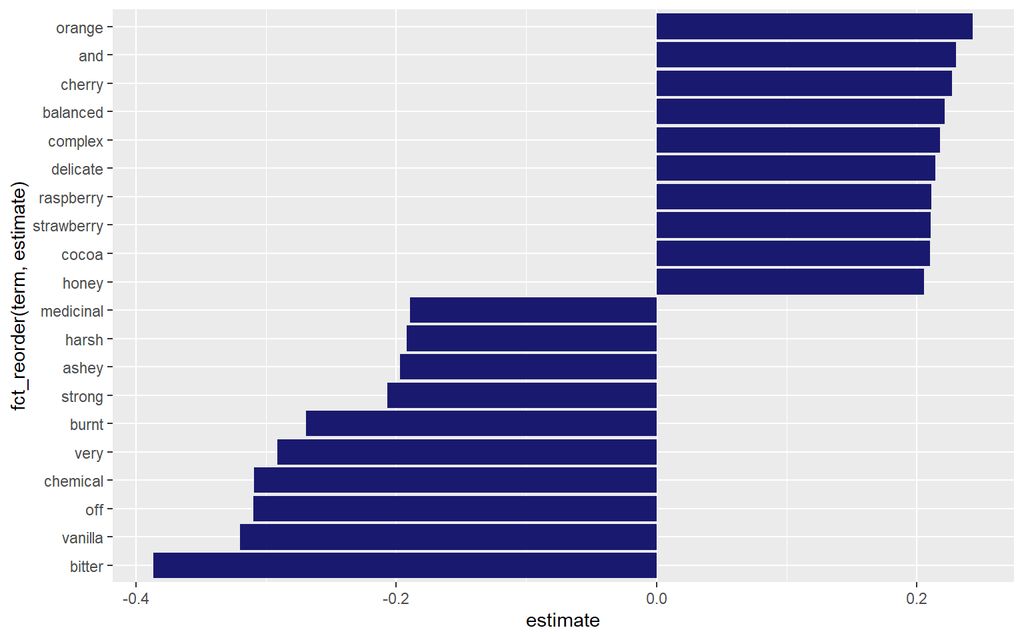

```r
svm_last %>%
    extract_workflow() %>%
    tidy() %>%
    filter(term != "Bias") %>%
    mutate(term = str_remove(term, "tf_most_memorable_characteristics_")) %>%
    group_by(estimate > 0) %>%
    slice_max(abs(estimate), n = 10) %>%
    ungroup() %>%

    ggplot(aes(estimate, fct_reorder(term, estimate))) +
    geom_col(fill = "midnightblue")
```